# act_report

## **Data Analysis and Visualization on the Dog Rating Tweets**

Prepared by Mohamed Alsayed:

WeRateDogs is a twitter account dedicated mostly on rating dogs picture on the internet. It has been a popular account, not only due to the dog picture it posted, but also because of the unique rating system that they are using. In this analysis, we are trying to gain interesting facts among the dogs captured in the tweets and also the result of the image prediction made from the dogs, which generates 3 most popular tags for each dogs.

**What are the most popular dog names in the dog tweet rates?**

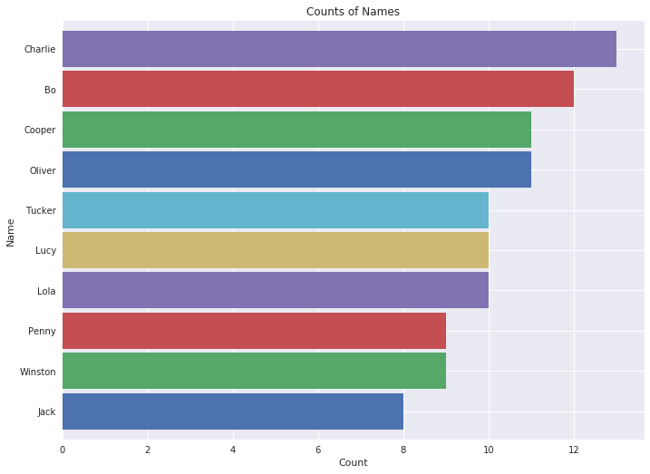

Based on the above histogram, Charlie is the most popular name, followed by Bo and cooper

**what is the correlation between retweet count and favorite count?**

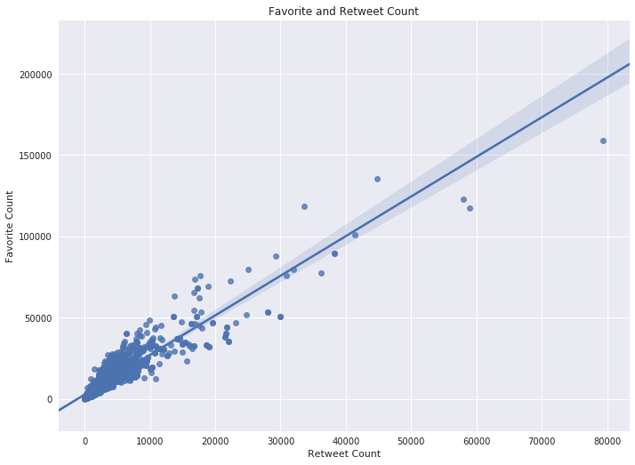

From the above Regplot, its clear there is a correlation between favorite count and retweet count.

**what patterns for the rating given in the tweet?**

based on the time the tweet was made.

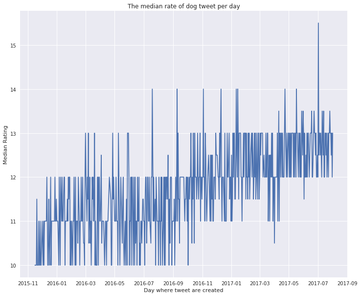

The above plot, not clear enough, it indicate an increase in the rating of the dog given. We will it divide it to bigger interval.

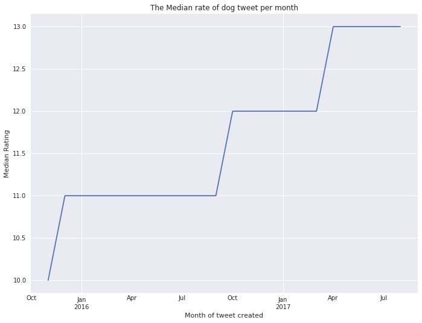

From the above plot, the rating given to dogs increases by time.

**Does @weRateDogs tweets get more tweets by popularity?**

Let's first plot the number of tweet data per month.

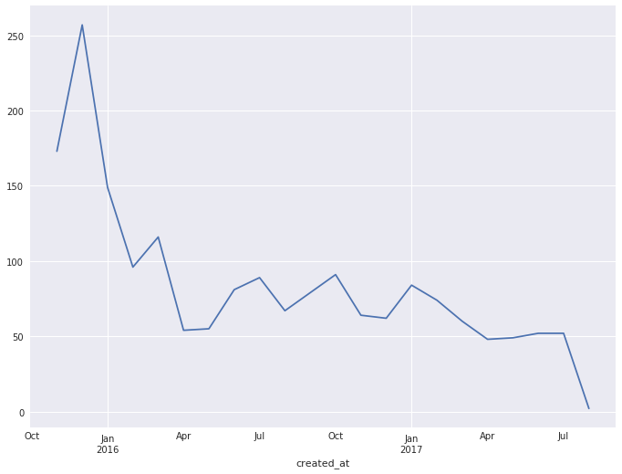

**what about the retweet count and the favorite count per month?**

To measure the account popularity, its better to use median of the retweet count and favorite count instead of the sum, as median is less affected by outlier and the sum may be affected by the number of tweets made per month, which differs each month.

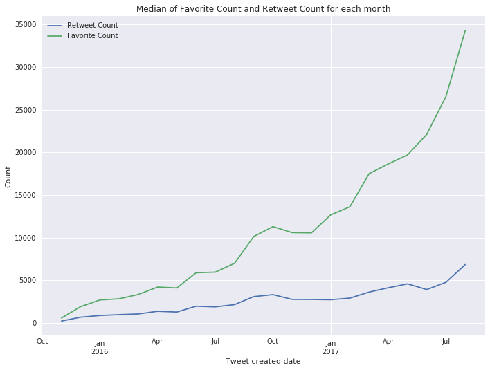

From the above, we can see that there is retweet count and favorite count is increasing, despite the decrease of the number of dog rating tweet made.

**How about confidence is the image prediction?**

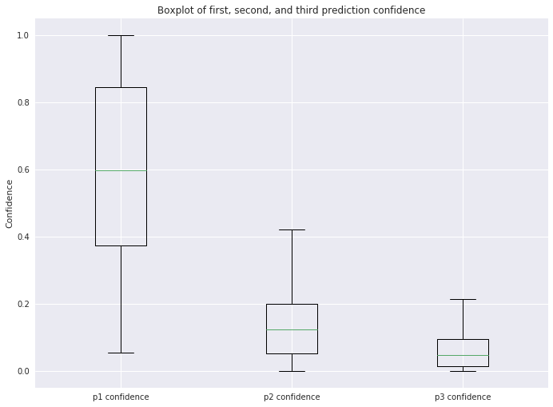

From the above boxplot, we can see that first prediction tend to have higher confidence than the second and third prediction. We can also see that for the first prediction is more than 50% of the image has more than 50% confidence.